# Seminarska naloga 1

Tanja Gošnjak

2023-11-13

## Uvod

V seminarski nalogi se bomo ukvarjali z izračunom zlatega reza $\phi$, ki je definiran kot
$$ϕ= \frac{1+\sqrt{5}}{2}$$
. Za ocenjevanje zlatega reza bomo uporabili metodo Monte Carlo. Metoda Monte Carlo je simulacijska metoda, kjer lahko s pomočjo naključnih točk in ponavljanj metode ocenimo ploščino likov in rešujemo zapletene matematične probleme. Primer uporabe metode bomo najprej predstavili na primeru izračuna števila $\pi$.

```r
#generiramo naključno točko v kvadratu
nakljucna_tocka = function(){
  x = runif(1, -1, 1)
  y = runif(1, -1, 1)
  return(c(x, y))
}

#preverimo, ali točka leži znotraj krožnice
tockavkrogu = function(a, b){
  sredisce_x = 0
  sredisce_y = 0
  polmer = 1

  #c^2 = a^2 + b^2
  if (a>=(sredisce_x-polmer)){
    x_kvadrat = (sredisce_x-(a))^2
    y_kvadrat = (sredisce_y-(b))^2
    razdalja = sqrt(x_kvadrat + y_kvadrat)

    if (razdalja <= polmer){
      result = TRUE
    }else{
      result = FALSE
    }
  }

  if (a<sredisce_x-polmer){
    result = FALSE
  }
  return(result)
}

#generiramo veliko točk in preverjamo, ali ta leži v krogu
znotraj=0
stposkusov=1000000
for (i in 1:stposkusov){
  tocka = nakljucna_tocka()
  a = tocka[1]
  b = tocka[2]

  vkrogu = tockavkrogu(a, b)

  if (vkrogu == TRUE){
    znotraj = znotraj + 1
  }
}

#delež števila točk znotraj kroga pomnožimo s 4 in dobimo približek števila Pi
delez = znotraj/stposkusov * 4

delez
```

```
## [1] 3.138052
```

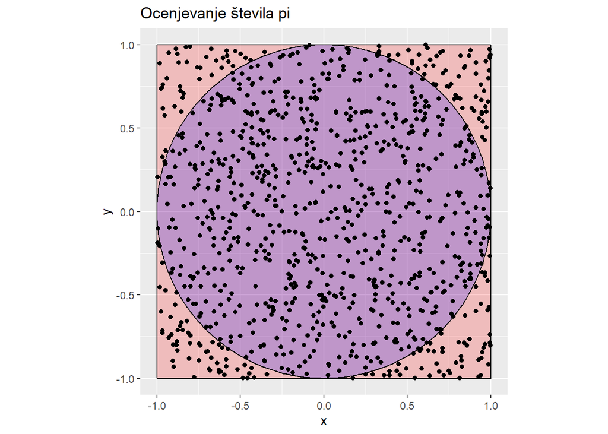

Pri primeru imamo kvadrat velikosti 2×2, v katerem je vrisan krog s polmerom 1 (sredične kroga in središče krožnice sta enaka). Če generiramo naključne točke v kvadratu in nas zanima verjetnost, koliko od teh točk pade v krožnico, bi to izračunali kot ploščina krožnice deljeno s ploščino kvadrata. Verjetnost, da zadanemo krog (oziroma ploščina kroga/ploščina pravokotnika), bi po izračunu bila $\pi$ četrtin. V naši simulaciji smo tako generirali točke na območju, ki ga omejuje kradrat [-1,1]×[-1,1] in preverjamo, katere točke so znotraj kroga (x^2 + y^2 = 1). Število točk, ki ležijo v krogu, smo delili z vsemi generiranimi točkami. Delež, ki ga dobimo je zato približek vrednosti ploščine kroga s ploščino kvadrata oziroma $\pi$ četrtin. Vrednost, ki smo jo dobili, smo množili s 4, da dobili približek štrevila $\pi$ (3,14).

## Prvi način

```r
rtocka1 = function(){
  # točka v pravokotniku [0, 1] × [0, 2]
  ax=1
  ay=2
  x = runif(1, min=0, max=ax)
  y = runif(1, min=0, max=ay)
  return(c(x, y))
}

# določimo ploscino pravokotnika
plPrav =  1*2

# enakokraki trikotnik
# določimo npr. a = 1


a = 1
kot = (pi-(2*((2*pi)/5)))/2
#izračun višine trikotnika
Va = (a/2)/tan(kot)

# določim koordinate trikotnika
A = c(0, 0)
B = c(1, 0)
C = c((A[1]+B[1])/2, Va)

ploscinaT = function(A, B, C){
  x1 = A[1]
  x2 = B[1]
  x3 = C[1]
  y1 = A[2]
  y2 = B[2]
  y3 = C[2]

  ploscina = abs((x1 * (y2 - y3) + x2 * (y3 - y1) +
                    x3 * (y1 - y2)) / 2)

  return(ploscina)
}


# ploscinaT(A, B, C)

vtrikotniku = function(A, B, C, P){

  # ploščina triktonika ABC
  p1 = ploscinaT(A, B, C)

  # ploščina trikotnika PBC
  p2 = ploscinaT(P, B, C)

  # ploščina trikotnika PAC
  p3 = ploscinaT(P, A, C)

  # ploščina trikotnika PAB
  p4 = ploscinaT(P, A, B)

  # preveri, če je vsota ploščin p2, p3 in p4 enaka p1
  if (p1 == p2 + p3 + p4){
    znotraj = TRUE
  }
    else{
      znotraj = FALSE
    }

  return(znotraj)
}

# vtrikotniku(A, B, C, c(0,0))


preveriznotraj = function(n){
  znotraj=0
  for (i in 1:n){
    tocka = rtocka1()
    a = tocka[1]
    b = tocka[2]

    trikotnik = vtrikotniku(A, B, C, c(a, b))

    if (trikotnik == TRUE){
      znotraj = znotraj + 1
    }
  }

  plPrav = 2
  delez = znotraj/n

  # množimo s konstanto, ki nam na koncu da rezultat zlatega reza
  # zlatirez = (delez točk v trikotniku * 2 * ploščina pravokotnika)/(a^2 * cos(pi/10))
  zlatirez = (delez*2*plPrav)/(1^2 * cos(pi/10))

  return(zlatirez)
}


n=10000

preveriznotraj(n)
```

```
## [1] 1.591073
```

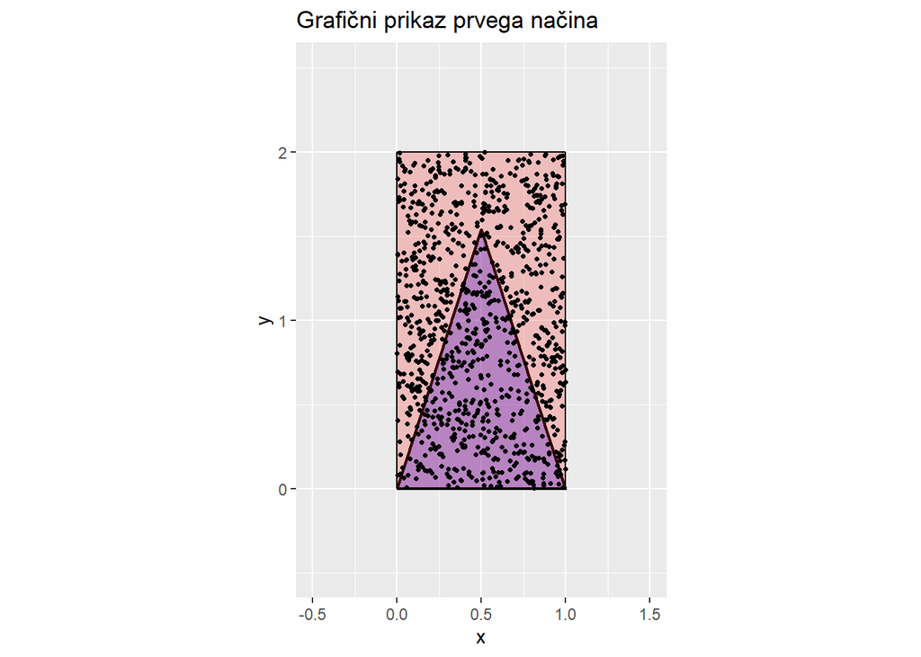

Pri prvem načinu smo v koordinatni sistem v pravokotnik vrisali trikotnik s kotom $\alpha$ = 2$\pi$/5 in osnovno stranico a=1. Za ploščino trikotnika je veljala enačba
$$A =
ϕ \cdot a^2 \cdot cos(π/10)/2.$$
Zanimala nas je ploščina trikotnika. To smo računali na enak način kot pri krogu v prejšnjem primeru. Gre za to, da lahko ploščino trikotnka izračunamo, če poznamo velikost pravokotnika in delež trikotnika v tem pravokotniku. Če generiramo naključne točke, je verjetnost, da zadane triktonik, ravno enaka deležu trikotnika v tem pravokotniku. Generirali smo veliko število točk, za katere smo preverjali, ali pade v trikotnik ali ne. Če točka P pade v trikotnik, pomeni, da je seštevek ploščin PBC, PAC in PAB enaka ploščini ABC. Število točk, ki so padle v trikotnik smo delili s številom generiranih točk in dobili razmerje, ki predstavlja oceno razmerja med ploščino trikotnika in ploščino pravokotnika. Iz razmerij ploščin trikotnika in pravokotnika smo izrazili zlati rez in izračunali njegov približek (1,6).

## Drugi način

```r
rtocka2 = function(){
  # točka v pravokotniku [0, 0.5] × [0, 1.5]
  ax=0.5
  ay=1.5
  x = runif(1, min=0, max=ax)
  y = runif(1, min=0, max=ay)
  return(c(x, y))
}

# rtocka2()

plPravokotnikI = 0.5 * 1.5

# funkcija pod katero ploščino primerjamo
f = function(x) 1/sqrt(1+x^2)

P = c(0, 0.5)

podkrivuljo = function(P){
  # preverimo ali je vrednost v točki P manjša ali enaka
  # vrednosti funkcije pod krivuljo
  f_y = 1/sqrt(1+P[1]^2)
  if (P[2] <= f_y){
    znotraj = TRUE
  }else{
    znotraj = F
  }
  return(znotraj)
}

preveripodkrivuljo = function(n){
  # točko v pravokotniku generiramo n-krat
  znotraj=0
  for (i in 1:n){
    tocka = rtocka2()
    a = tocka[1]
    b = tocka[2]


    integral = podkrivuljo(c(a, b))

    # seštevamo število točk, ki ležijo pod krivuljo
    if (integral == TRUE){
      znotraj = znotraj + 1
    }
  }

  plPravokotnikI = 0.5 * 1.5
  delezintegral = znotraj/n

  # izračunamo zlati rez glede na podano zvezo
  ploscina = delezintegral*plPravokotnikI

  zlatirezI = exp(ploscina)

  return(zlatirezI)
}


n=10000

preveripodkrivuljo(n)
```

```
## [1] 1.618258
```

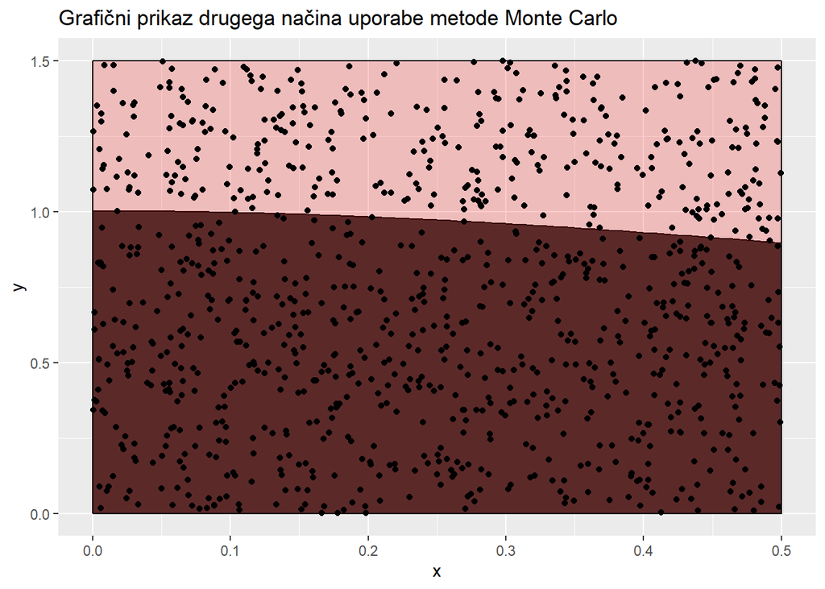

V drugem načinu smo generirali točke znotraj pravokotnika v odmočju od x=0 do x=0.5, kjer velja zveza
$$log(ϕ) =
\int_{0}^{0.5}{\frac{1}{\sqrt{1+x^2}} dx}$$
. Izračunali smo delež točk pod krivuljo z vsemi generiranimi točkami. Pri tem smo enako uporabili dejstvo, da je verjetnost točk, ki padejo pod krivuljo glede na pravokotnik, enaka deležu površine pod krivuljo s pravokotnikom. Iz izračuna deleža in podane zveze smo lahko izrazili in izračunali oceno zlatega reza.

## Primerjava

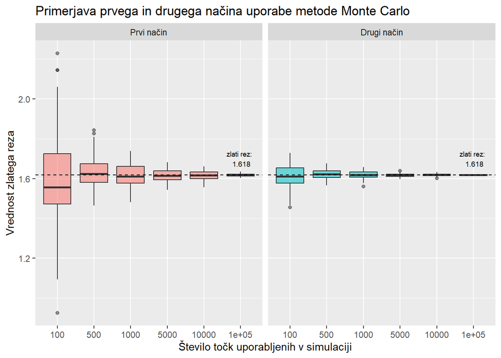

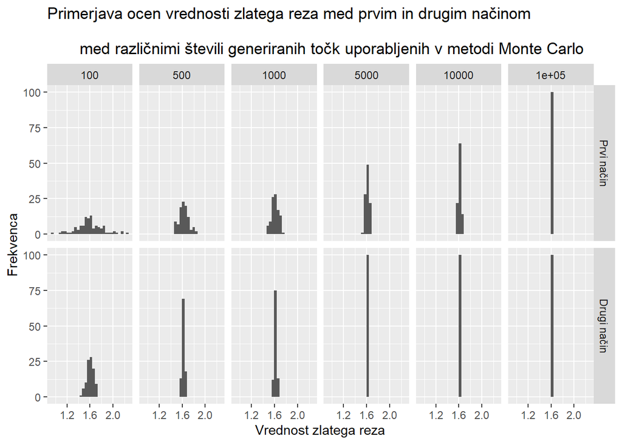

Na sliki so predstavljni histogrami generiranih ocen pri vseh velikostih vzorca za oba načina. Enako opazimo, da so z večanjem števila generiranih točk, te bolj skoncentrirano razporejene okoli prave vrednosti zlatega reza. Poleg tega vidimo, da je ocenjevanje z drugim načinom bolj natančno, saj so vrednosti tudi pri manjšem vzorcu generiranih točk manj razpršene okoli pričakovane vrednosti. Na velikost ocene vpliva velikost pravokotnika, v katerem generiramo točke. Z večanjem površine, ki je ne zasede lik, katerega ploščino ocenjujemo, se veča razpršenost točk okoli pričakovane vrednosti. Razlog je v tem, da lik zasede manjši del celotne površine, kjer generiramo točke, kar pa vpliva na to, da je pri manjšem številu točk, ki jih generiramo, manjša verjetnost, da bo zadela območje, ki ga ocenjujemo.

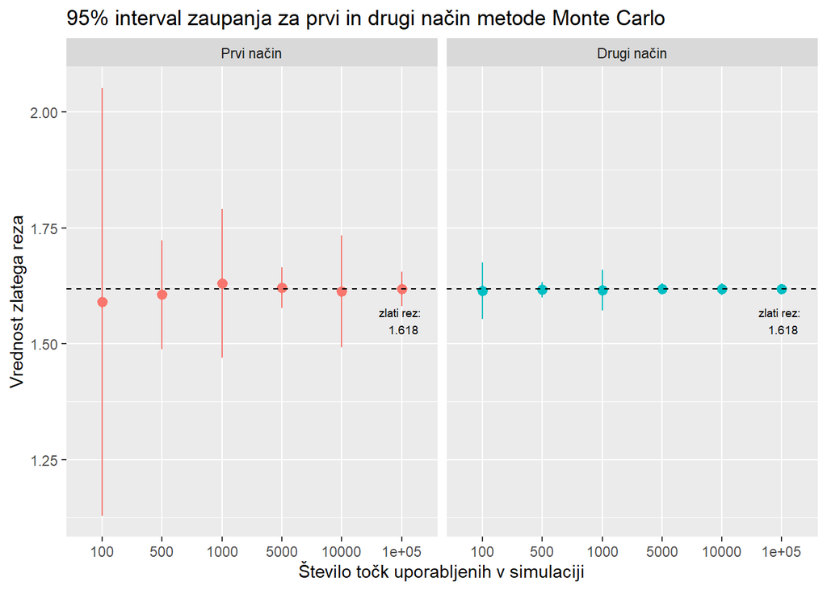

## Zaključek

Ugotovili smo, da je metoda Monte Carlo uporabna metoda za ocenjevanje zlatega reza. Pri tem smo morali poznati zvezo s katero je vrednost zlatega reza povezana s površino na grafu. Ugotovili smo, da je ocenjevanje natančenjše z večanjem števila generiranih točk, kar je povezano s standardno napako, ki je pri večjih vzorcih, manjša. Na ocenjevanje vpliva tudi velikost ploščine, ki jo ocenjujemo glede na velikost pravokotnika. Če lik zasede manjši delež pravokotnika, v katerem generiramo naključne točke, je ocenjena verjetnost slabša, predvsem pri manjših vzorcih. Pri generiranju naključnih točk pa se lahko vprašamo tudi, do katere meje so točke zares generirane naključno, kar je bistvena karakteristika metode Monte Carlo.